# Coursera Capstone Word Prediction Project

Ioannis Petridis  
7th of January, 2019

### Project Goal

Around the world, people are spending an increasing amount of time on their mobile devices for email, social networking, banking and a whole range of other activities. But typing on mobile devices can be a serious pain. SwiftKey, a corporate partner in this capstone, builds a smart keyboard that makes it easier for people to type on their mobile devices. One cornerstone of their smart keyboard is predictive text models which will be the goal of this project

### Product Description

The “Word Prediction” application is the answer to the problem.

### Guide through the application

Steps:

1) When the application loads fill in the words for which you need a prediction

2) Press the submit button or enter

3) The next predicted word appears

### Screenshots of the application(1/3)

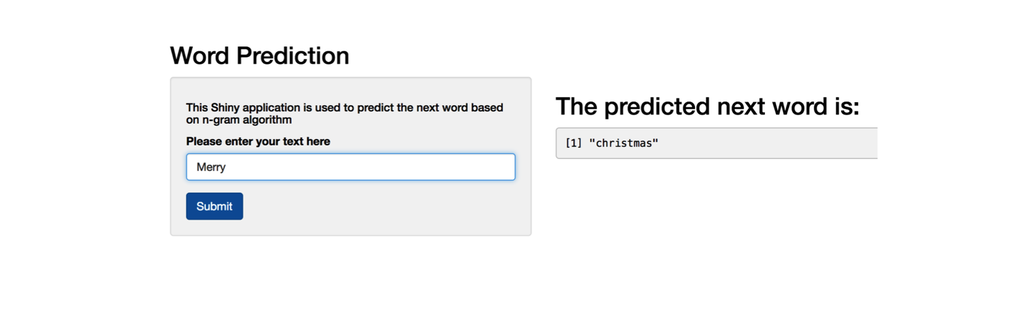

### Screenshots of the application(2/3)

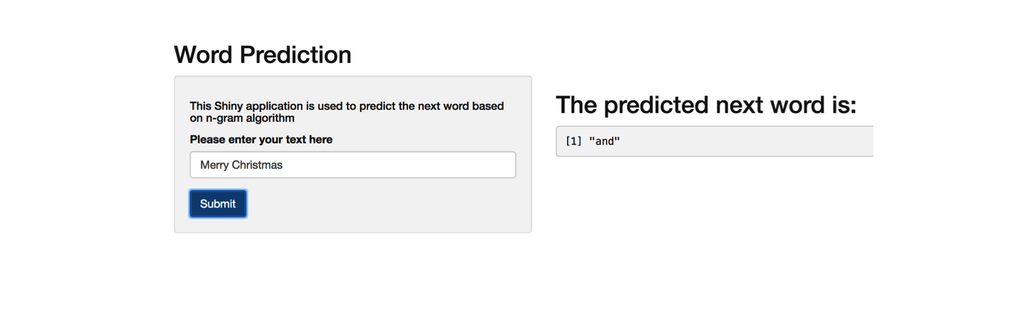

### Screenshots of the application(3/3)

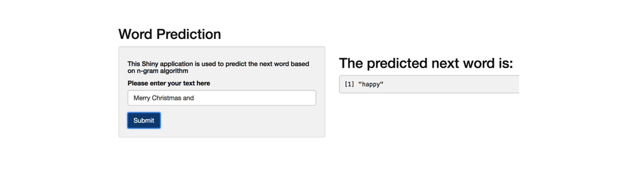

### Screenshots of the application(1/2)

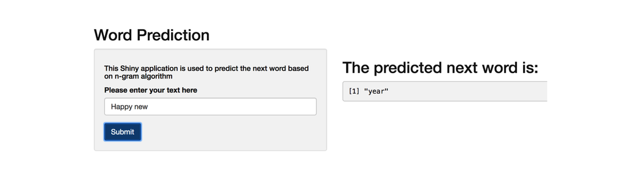

### Screenshots of the application(2/2)

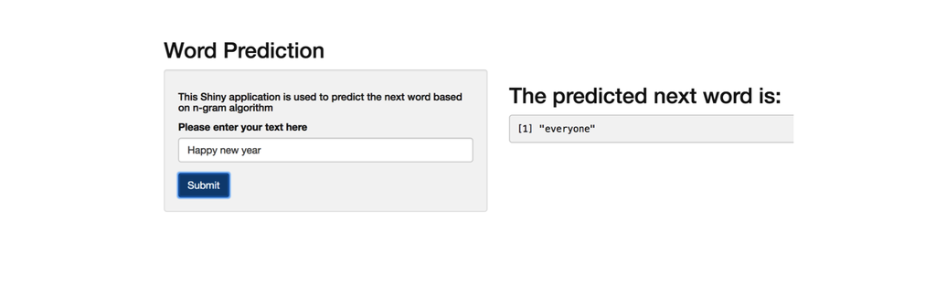

### Useful links

- Github Repo: https://github.com/iopetrid/DataScience_Capstone
- Shiny App: https://iopetrid.shinyapps.io/Capstone_PredictWords/